# Deterministic Modeling

```python
import numpy as np, matplotlib.pyplot as pl
```

## Truncation errors

Deterministic refers to the ability of a method or a calculation to have the results solely determined by its sets of input parameters. In certain conditions, mathematics gives us gives us guarantees in the form of uniqueness and converges results. For example, set aside round-off errors, we know that the roots of a quadratic equation are linked one-to-one with its coefficients.

In many cases, the mathematical solution of a physics problem is expressed as a limit process that takes an infinite number of steps. A computer implementation is, of course limited not only in terms of finite number of digits in real numbers representation, but also also in terms on number of steps that can be taken. This is because, event though computers are fast, the time a certain numerical operation takes is still finite.

**Truncation error** is the difference between the exact mathematical results anticipated in the limit process and the calculation that uses a finite number of steps. A computation may be in principle made more exact by increasing the number of steps, but the price to be paid for this in computer time. Often, a compromise between speed and accuracy is need. When this is not acceptable, then a new method, introducing some extra assumptions or approximations may be required such that some progress towards a solution is obtained.

New approximations introduce new kind of errors. The situation is even worse when the convergence of the methods may be weak or non-uniform. And if we include in this the round-off errors, which will seriously accumulate when increasing the number of step, then we are in serious trouble.

How fast are the computers anyway?

For example, suppose we want to multiply two $N\times N$ matrices represented as arrays *A* and *B* and obtain the matrix *C* as a result. Mathematically this is

$$C_{ij} = \sum_{k=1}^N A_{ik} B_{kj}$$

A simple Pyhton code (we use it her just for illustration, in real-life we would use numpy) may be

```python
N = 100
A = np.random.rand(N,N)
B = np.random.rand(N,N)
C = np.zeros([N,N])

for i in range(N):
    for j in range(N):
        for k in range(N):
            C[i, j] += A[i,k]*B[k,j]
```

This program has 3 nested loops. The inner loop, which runs through values of variable `k` in summation, does one multiplication and one addition each time, for a total of 2N operations. The j loop requires $2N^2$ operations, and therefore the overall number of operations for obtaining the result in variable `C` is $2N^3$. For N=1000, the whole calculation requires 2 billion operations and probably takes few minutes to finish.

The amount of time may vary from one computer to another and may depend on what programming is used, but we can say that the program finishes in a time of the order of $t = K \times N^3$, with some constant $K$. Instead of this simple procedure, we can use numpys specialized `dot` function, but that will only change the constant $K$. Doubling the size of matrices will still take 8 times longer!

What can we do to obtain results for difficult problems. There are 3 ways:

1. Optimize those parts of the program that take longer to execute. This can be done by an activity called **profiling**. Python has a number of tools that can be used for that.
2. Invent a better algorithm, or relax some of the approximations or constraints use in your problem. Publish your work. Solving differential equations with a computer is still an active area of research.
3. Assemble an army of processors and make them collaborate to get the result. Sometimes this can be done in an obvious way, say we need to solve a quadratic equation 1000 time and we have 10 computers. Some problem are harder to solve in a parallel way. This is how a supercomputer works, as of 2021, the fastest computer in the world is in Japan, uses 158,976 CPU cores at has a peak performance of about 400 PFLOPS ($10^{15}$ FLOPS). (https://www.top500.org)

### Madelung Constant

An ionic solid, like sodium-chloride has positive and and negative ions attracting each other forming a packed periodic structure. In this cubic lattice, sodium atoms with charge *+e* alternate with chlorine atoms with negative *-e* charge. The energy required to break these bonds for one mole of ionic solid under standard conditions is the **lattice energy**.

[figure not shown]

To calculate the lattice energy it is enough to evaluate the potential energy of a single atom in the electric field created by all other atoms around it. If we label each position on the lattice by three integer coordinates *(i,j,k)* the sodium atoms fall at positions where *i+j+k* is even, and the chlorine atoms at positions where *i+j+k* is odd.

Since the lattice is infinite, we can focus on a sodium atom a the origin *i=j=k=0*, and calculate the electric potential created by all other atoms at the origin:

$$V_\text{origin} = \sum_{i,j,k=-L}^L {\vphantom{\sum}}' \quad V(i,j,k)$$

with ' indicating that the origin itself is excluded from summation. The contribution from the *(i,j,k)* location that is at a distance *r(i,j,k)* from the origin is

$$V(i, j, k) = \frac{q(i,j,k)}{4\pi\epsilon_0 r(i,j,k)} = \frac{(-1)^{i+j+k} e}{4\pi\epsilon_0 a \sqrt{i^2+j^2+k^2}}$$

where *a* is the lattice constant, the distance to the nearest neighbor, and $\epsilon_0$ is the vacuum electric permittivity ($k_e = 1/4\pi\epsilon_0$). The electric potential at the origin is therefore

$$V_\text{origin} = \frac{e}{4\pi\epsilon_0 a} M$$

The Madelung constant *M* is therefore an universal constant equal in principle with the $L\rightarrow\infty$ limit of

$$M = \sum_{i,j,k=-L}^L {\vphantom{\sum}}' \quad\frac{(-1)^{i+j+k}}{\sqrt{i^2+j^2+k^2}}$$

Here is a simplistic implementation for the calculation of Madelung constant. The 3D grid has (2L)^3, assuming that the calculation at each point takes about the same amount, the total amount of time to obtain a result could be modeled with the formula $$t_L = \text{const} \times L^3$$ The power 3 is very important here because it dictates how precise the result can be. By doubling $L$, we hope to improve the accuracy of the result, but we expect that the time required to be 8 times longer.

To check this law of increasing time with the order of approximation, we run a series of calculation with doubling the size of the grid at each step and calculating the logarithm (in base 2) of time required for execution. Assuming that $t_L = \text{const} \times L^\beta$, and that $L = 4 \times 2^k$, we expect that

$$\log_2(t_k) = {const} + \beta\; k$$

Therefore $\beta$ is the slope in a $\log(t_k)$ vs $k$ representation.

In order to avoid dividing by zero, but keeping `numpy`'s advantage of working with arrays, we change the square distances array `W` to infinity for the grid point corresponding to the origin, such that `1/sqrt(W)` is finite everywhere. First, `W == 0` returns an array of booleans with `True` at positions where `W` is zero, then the notation `W[array_of_booleans]` selects a set of elements that are 'True' at the same position in the `array_of_booleans` and make assignments only to those elements.

```python
import time

def madelung(L):
    x = np.arange(-L,L+1)
    y = np.arange(-L,L+1)
    z = np.arange(-L,L+1)
    X, Y, Z = np.meshgrid(x,y,z)
    W = (X**2 + Y**2 + Z**2).astype(np.float64)
    W[W == 0] = np.Infinity
    return(np.sum((-1)**((X+Y+Z) % 2)/np.sqrt(W)))

for k in range(7):
    L = 2**k*4
    now = time.time()
    M = madelung(L)
    duration = time.time() - now
    print(f"k = {k} log2(t) = {np.log2(duration):6.2f},  M = {M}")
```

```
k = 0 log2(t) = -10.06,  M = -1.6192696788703982
k = 1 log2(t) =  -9.70,  M = -1.6796412454744896
k = 2 log2(t) =  -7.85,  M = -1.712573676887853
k = 3 log2(t) =  -5.14,  M = -1.7297999712239167
k = 4 log2(t) =  -2.72,  M = -1.7386134276774186
k = 5 log2(t) =   0.20,  M = -1.7430715964296657
k = 6 log2(t) =   3.66,  M = -1.7453137163907422
```

Indeed, direct calculation confirms that $\beta \approx 3$ and the constant converges slowly towards 1.74756, although a lot more computer time would be required to achieve some decent accuracy. This is terrible! A smarter way of summing over the 3D grid is required. It was proposed, that instead of expending over cubes with larger and larger sizes, a simpler approach would include only grid points within a sphere, and then make the radius larger and larger. This is easier to implement, but gives worse results. By summing over expanding spheres, the Madelung constant approximation does not even converge! This is because the series is only **conditionally convergent**, its convergence depends on the specified order of summation.

## Geometry: Ray Tracing

**Ray Tracing** is a realistic rendering technique that is based on basics optics concepts like straight line propagation of light and reflection law. It effectively simulates the formation of an image in an optical device such as the eye, or a camera.

This technique is heavily used in animation movie and video games industries. Newest video cards have hardware than can do ray tracing, allowing the CPU to do other things.

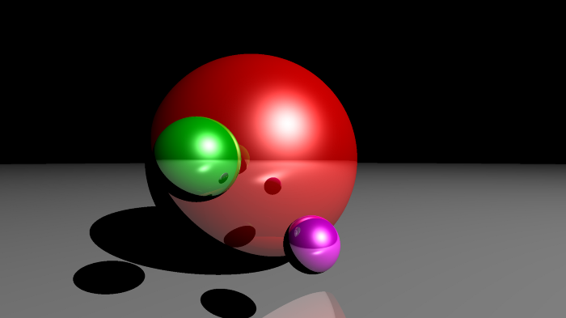

The elements of a ray tracing simulation are:

- the camera is simply an array of pixels, with optics attached that can have focal distance, distortion and other parameters,
- 3D objects placed in the field of view that can be defined in terms of 3D geometric primitives, such as spheres, cones, boxes. Each object has optical properties such as transparency, specularity or color,
- sources of light that can have intensity and color parameters.

Image is formed by light generated by sources, interacting with world objects and eventually activating sensitive pixels in the image forming device. Since the overwhelming majority of light rays from a given light source do not make it directly into the viewer's eye, a "forward" simulation could potentially waste a tremendous amount of computation on light paths that are never recorded.

A more practical way of simulating the image forming is to send rays *backward* away from that camera, rather than *into it*. Because of time reversibility of light propagation equations (Maxwell's equations) the direction of propagation of light is not relevant.

The algorithm start with each pixel of the camera dark and tries to establish its color by tracing backward the ray of light that eventually ends up at a source of light through multiple reflections or refractions.

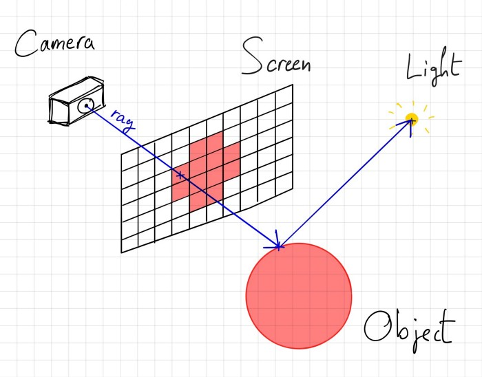

The main steps of the algorithm are described by the following pseudo-code:

```
for each pixel p(x,y) of the screen:
    associate a black color
    if the ray (line) that starts at camera and goes towards p intersects any object of the scene then:
        calculate the intersection point to the nearest object
        if there is no object of the scene in-between the intersection point and the light source then:
            calculate the color of the intersection point
            associate the color of the intersection point to p
```

In an introductory physics course it is explained that light simply reflects from a surface in strict geometrical way with the incident angle equal to the reflected angle. This law applies to mirrors. Light interacts with other surfaces in a more complicated way on many factors. The reasons why milk and a piece of paper are white are totally different.

The photo-sensitive area (the screen) is placed in the xOy plane, the camera is placed at position (0,0,1), while the rest of the world, is normally in the *z < 0* semi-space.

We use a sphere with a very large radius as a table on that supports 3 balls.

```python
import numpy as np, IPython.display
import matplotlib.pyplot as pl

def normalize(vector):
    return vector / np.linalg.norm(vector)

def reflected(vector, axis):
    return vector - 2 * np.dot(vector, axis) * axis

def sphere_intersect(center, radius, ray_origin, ray_direction):
    b = 2 * np.dot(ray_direction, ray_origin - center)
    c = np.linalg.norm(ray_origin - center) ** 2 - radius ** 2
    delta = b ** 2 - 4 * c
    if delta > 0:
        q = -(b + np.sign(b)*np.sqrt(delta))/2
        t1 = q
        t2 = c/q
        if t1 > 0 and t2 > 0:
            return min(t1, t2)
    return None

def nearest_intersected_object(objects, ray_origin, ray_direction):
    distances = [sphere_intersect(obj['center'], obj['radius'], ray_origin, ray_direction) for obj in objects]
    nearest_object = None
    min_distance = np.inf
    for index, distance in enumerate(distances):
        if distance and distance < min_distance:
            min_distance = distance
            nearest_object = objects[index]
    return nearest_object, min_distance

width = 300
height = 200

max_depth = 3

camera = np.array([0, 0, 1])
ratio = float(width) / height
screen = (-1, 1 / ratio, 1, -1 / ratio) # left, top, right, bottom

light = { 'position': np.array([5, 5, 5]), 'ambient': np.array([1, 1, 1]), 'diffuse': np.array([1, 1, 1]), 'specular': np.array([1, 1, 1]) }

objects = [
    { 'center': np.array([-0.2, 0, -1]), 'radius': 0.7, 'ambient': np.array([0.1, 0, 0]), 'diffuse': np.array([0.7, 0, 0]), 'specular': np.array([1, 1, 1]), 'shininess': 100, 'reflection': 0.5 },
    { 'center': np.array([0.1, -0.3, 0]), 'radius': 0.1, 'ambient': np.array([0.1, 0, 0.1]), 'diffuse': np.array([0.7, 0, 0.7]), 'specular': np.array([1, 1, 1]), 'shininess': 100, 'reflection': 0.5 },
    { 'center': np.array([-0.3, 0, 0]), 'radius': 0.15, 'ambient': np.array([0, 0.1, 0]), 'diffuse': np.array([0, 0.6, 0]), 'specular': np.array([1, 1, 1]), 'shininess': 100, 'reflection': 0.5 },
    { 'center': np.array([0, -9000, 0]), 'radius': 9000 - 0.7, 'ambient': np.array([0.1, 0.1, 0.1]), 'diffuse': np.array([0.6, 0.6, 0.6]), 'specular': np.array([1, 1, 1]), 'shininess': 100, 'reflection': 0.5 }
]

image = np.zeros((height, width, 3))
```

The equation of a ray (line) that passes through two 3D points O (origin) and D (destination) is given by

$$ {\vec r}(t) = O + \frac{D - O}{|D - O|} t = O + {\vec d} t$$

,

where we defined $\vec d$ as the unit magnitude direction vector.

Next, we need to decide if a given ray intersect with a sphere from the model. A sphere with radius $R$ and centered on point *C* is defined by all points P such that $|| P - C||^2 = R^2$. Therefore, to find the intersection of ray with a sphere we need to solve the following equation:

$$||{\vec r}(t) - C||^2 = R^2$$

which means we need to find t

$$||O + {\vec d} t - C||^2 = R^2$$

as a solution of a quadratic equation: $$ ( O + {\vec d} t - C) \cdot (O + {\vec d} t - C) = d^2 t^2 +2 t {\vec d}\cdot {\vec {OC}} + {\vec{OC}}^2 = R^2$$

The function `sphere_intersect` calculates intersection points, if any. The discriminant decides the number of intersections:

$$\Delta = ({\vec d}\cdot {\vec {OC}})^2 + R^2 - {\vec{OC}}^2 $$

since $d^2 = 1$.

[figure not shown]

The function `nearest_intersected_object` loops over all spheres in the model and chooses the nearest one to the camera.

Using again the function `nearest_intersected_object` we can now start from the intersection point and try to trace back to the source and detect if any other object is in between, making the intersection point invisible by being in the shadow of some other object.

If the ray that starts from the camera strikes an object and has a direct line of view towards a light source, then the corresponding pixel gets a color that depends on the specific reflection model for the object surface.

Blinn-Phong model is a simple reflection model describing the reflected light by 4 parameters:

- **Ambient color** $k_a$: color that an object is suppose to have in absence of light. It’s hard to imagine, since we only see objects when light strikes on them, but generally this is a dim color tinted with the actual color you imagine;
- **Diffuse color** $k_d$: color that is the closest to what we think of when we say “color”;
- **Specular color** $k_s$: color of the shiny part of an object when light has stroke on it. Most of the time this is white;
- **Shininess** $\alpha$: a coefficient representing how shiny an object is.

The illumination of a point in Blinn-Phong model is an (R,G,B) triplet calculated according to:

$$I_p = k_a i_a + k_d i_d {\bf L}\cdot {\bf N} + k_s i_s \left(\frac{{\bf N} \cdot ({\bf L} + \bf{V})}{|{\bf L} + {\bf V}|}\right)^{\alpha/4}$$

where ${\bf L}$ is the unit vector toward the light source, ${\bf N}$ is the unit vector normal to the surface and ${\bf V}$ is the unit vector towards the camera. ${i_a}$, ${i_d}$ and ${i_s}$ are the ambient, diffuse, specular properties of the light.

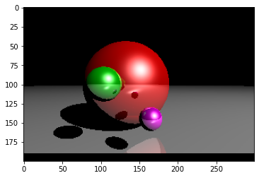

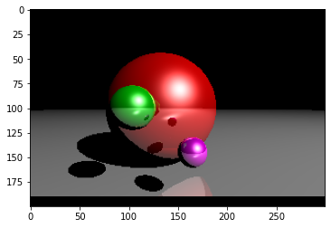

```python
for i, y in enumerate(np.linspace(screen[1], screen[3], height)):
    if i%10 == 0:
        pl.imshow(image)
        IPython.display.clear_output(wait=True)
        IPython.display.display(pl.gcf())
    for j, x in enumerate(np.linspace(screen[0], screen[2], width)):
        # screen is on origin
        pixel = np.array([x, y, 0])
        origin = camera
        direction = normalize(pixel - origin)

        color = np.zeros((3))
        reflection = 1

        for k in range(max_depth):
            # check for intersections
            nearest_object, min_distance = nearest_intersected_object(objects, origin, direction)
            if nearest_object is None:
                break

            intersection = origin + min_distance * direction
            normal_to_surface = normalize(intersection - nearest_object['center'])
            shifted_point = intersection + 1e-5 * normal_to_surface
            intersection_to_light = normalize(light['position'] - shifted_point)

            _, min_distance = nearest_intersected_object(objects, shifted_point, intersection_to_light)
            intersection_to_light_distance = np.linalg.norm(light['position'] - intersection)
            is_shadowed = min_distance < intersection_to_light_distance

            if is_shadowed:
                break
            illumination = np.zeros((3))
            # ambiant
            illumination += nearest_object['ambient'] * light['ambient']
            # diffuse
            illumination += nearest_object['diffuse'] * light['diffuse'] * np.dot(intersection_to_light, normal_to_surface)
            # specular
            intersection_to_camera = normalize(camera - intersection)
            H = normalize(intersection_to_light + intersection_to_camera)
            illumination += nearest_object['specular'] * light['specular'] * np.dot(normal_to_surface, H) ** (nearest_object['shininess'] / 4)
            # reflection
            color += reflection * illumination
            reflection *= nearest_object['reflection']

            origin = shifted_point
            direction = reflected(direction, normal_to_surface)

        image[i, j] = np.clip(color, 0, 1)
```

adapted from https://medium.com/swlh/ray-tracing-from-scratch-in-python-41670e6a96f9 .

## Interpolation

Given a set of N points $x_1, x_2,\ldots, x_N$, written in increasing order, and the value of a function $f(x)$ at these points $f(x_1), f(x_2), \ldots, f(x_N)$, we want to get $f(x)$ at an arbitrary point, where we don't have an analytic expression, or maybe these numbers were obtained from some physical measurement or from long expensive numerical calculation. The numbers $x_i$'s may be equally spaced, but not necessarily.

**Interpolation** is when the target point $x$ is between the smallest and the largest $x_i$: $x_1 \le x \le x_N$. When we seek the function at a value outside this range, the problem is called **Extrapolation**.

Since this procedure can be repeated at any point, we imagine that the result is a smooth curve that have to go through the given points. In general, interpolation has a much better chance to succeed than extrapolation. Without additional information about our unknown function, extrapolation is very likely to fail.

Mathematically, we seek our solution within a space (class) of functions that:

- is large enough, so that it can cover many possible cases
- are easy enough to work
- is sufficiently general
- have as many desired features as possible

The most common space is the space of polynomials. Rational functions are also extremely useful. *Trigonometric interpolation* refers to combinations of sin and cosines, forming the basis of Fourier methods to analyze harmonics composition (spectra).

Sometimes interpolation is straight forward, but pathological cases are encountered more often than one may think. Consider the function

$$f(x) = 3 x^2 + \frac 1{\pi^4} \ln [(\pi-x)^2] -30 $$

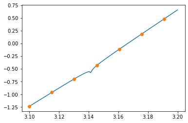

```python
f = lambda x: 3*x**2 + np.log((np.pi-x)**2)/np.pi**4 -30
xR = np.linspace(3.1,3.2,100)
pl.plot(xR, f(xR))
pl.plot(xR[::15], f(xR[::15]),'o')
```

This function is well-behaved everywhere except at $x=\pi$, where it has a singularity. An interpolation based on few points may miss completely the mark and give a very wrong answer at $x=\pi$.

**Linear interpolation** approximates the function by a collection of polynomials of degree 1. We call this an order 1 interpolation. Every two consecutive points are joint by straight lines. If $a$ and $b$ are two such points, where we know that the function has values $f(a)$ and $f(b)$, then the linear interpolation is given by

$$f(x) = \frac{b-x}{b-a} f(a) + \frac{x-a}{b-a} f(b)$$

In general, order $n$ interpolation takes $n+1$ consecutive point and joins them with a polynomial of order $n$. The general scheme is given by Lagrange's formula. Let's try to figure it out.

$$f(x) = \phi_1 (x) f(x_1) + \phi_2 (x) f(x_2) + \ldots + \phi_N (x) f(x_N)$$

where each $\phi(x)$ is a polynomial of order $N-1$ that need to specify some universal conditions. For example: $\phi_1(x_1) = 1$ and $\phi_1(x_k)=0$ for any other $k \neq 1$. In general,

$$\phi_j(x_k) = \delta_{jk}$$

Where Kroneker delta symbols $\delta_{jk}$ is 0 unless $j = k$, when is 1.

A polynomial that is zero at all nodes except $x_1$ is

$$ \phi_1(x) = C (x-x_2) (x-x_3) \ldots (x-x_N)$$

We find the constant $C$ by requiring that $\phi_1(x_1) = 1$, so

$$ \phi_1(x) = \frac{(x-x_2) (x-x_3) \ldots (x-x_N)}{(x_1-x_2) (x_1-x_3) \ldots (x_1-x_N)}$$

In general, then

$$\phi_j(x) = \prod_{k\neq j} \frac{(x-x_k)}{(x_j - x_k)}$$

This is all we need to solve the interpolation problem. Indeed, this would be sufficient, because we can write:

$$f(x) = \sum_{j=1}^N f_j \phi_j(x) \quad\rightarrow\quad f(x_k) = \sum_{j=1}^N f_j \delta_{jk} = f_k$$

This formula can be implemented in a straightforward way. Let's try something simple:

```python
def interpolation(x, X, Y):
    phi = [np.prod(np.delete(x-X,k)/np.delete(X[k]-X,k)) for k in range(len(X))]
    return(np.dot(phi, Y))
```

Here *x* is a position (number) where we want to get the interpolated value, and *X* and *Y* are our data arrays with $x_k$'s and $f(x_k)$'s. The numpy function `delete()` returns a copy of an array with the element at given index eliminated. The copy operation of an array is expensive and should be avoided.

Let's supposed we have to interpolate some data that comes from a Cauchy bell shape,

$$c(x) = \frac{\gamma/\pi}{(x-x_0)^2 + \gamma^2}$$

We sample some points, build the interpolation and find interpolated value within and outside sampling interval.

The Cauchy, a.k.a. Lorentz, distribution resembles the Gaussian shape and has the following properties:

- is normalized to have unit area
- $x_0$ is the position of the maximum
- $\gamma$ gives the half of the width
- the decrease of the wings $\sim 1/x^2$ is much slower then Gaussian's wing decrease
- unlike the Gaussian, it does **NOT** have a mean, or standard deviation

```
(0.0, 0.8)
```

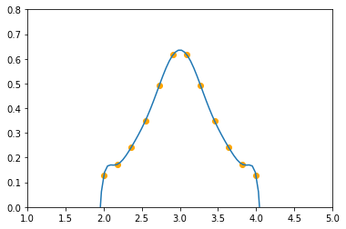

```python
x0 , γ = 3.0, 0.5
cauchy = lambda x: γ/np.pi/((x-x0)**2 + γ**2)

xS = np.linspace(2, 4, 12)
xR = np.linspace(1,5,100)

y_exact = cauchy(xS)

y_interpolated = [interpolation(x, xS, y_exact) for x in xR]

pl.plot(xS, y_exact,'o', color="orange", label="exact")
pl.plot(xR, y_interpolated)
pl.xlim(1,5); pl.ylim(0,0.8)
```

The *scipy* library has large amount of features useful for scientific computing. The interpolation package is carefully implemented and certainly more efficient than our quick solution. For a given data set we can obtain interpolants with various orders.

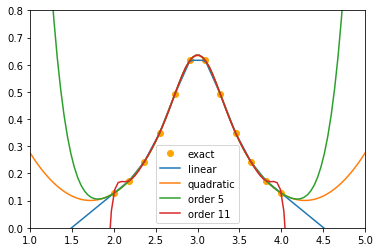

```python
import scipy.interpolate

# y_exact = cauchy(xS) + 0.04*np.random.rand(12) # sprinkle some noise
y_order1 = scipy.interpolate.interp1d(xS, y_exact, kind=1, fill_value="extrapolate")
y_order2 = scipy.interpolate.interp1d(xS, y_exact, kind=2, fill_value="extrapolate")
y_order5 = scipy.interpolate.interp1d(xS, y_exact, kind=5, fill_value="extrapolate")
y_order11 = scipy.interpolate.interp1d(xS, y_exact, kind=11, fill_value="extrapolate")

pl.plot(xS, y_exact,'o', color="orange", label="exact")
pl.plot(xR, y_order1(xR), label="linear")
pl.plot(xR, y_order2(xR), label="quadratic")
pl.plot(xR, y_order5(xR), label="order 5")
pl.plot(xR, y_order11(xR), label="order 11")
pl.xlim(1,5); pl.ylim(0,0.8)
pl.legend()
```

Here are some points about interpolation:

- the $x_k$ points are named *nodes* and don't have to be equally spaced
- interpolating functions are continuous
- the *n*-th derivate of interpolation of order *n-1* n is discontinuous
- interpolating function always passes through the data points
- increasing the order does not always lead to a better result
- interpolation function can oscillate wildly between the data points
- the fit gets worse toward the edges of the data set, and may totally miss the mark outside the range
- extrapolation can be disastrous. The **scipy** function `interp1d` does not even allow evaluation outside the range in a normal call. A special option `fill_value` needs to be given, otherwise **scipy** refuses to calculate an extrapolation.

**Splines** are polynomial interpolation functions for groups of nodes such that the continuity up the the maximum possible level is guaranteed by matching polynomial coefficients. The most popular spline is the **cubic spline** that gives piecewise polynomials of order 3, that go through all points and is continuous, together with the first and second derivative, resulting in a smooth interpolation.

**Rational function interpolation** is required for some functions that are not well approximated by polynomials. For example functions that have poles at some points. A Padé approximation is a rational function

$$R(x) = \frac{P_{m}(x)}{Q_n(x)} = \frac{p_0 + p_1 x + \ldots p_{m} x^m}{q_0 + q_1 x + \ldots q_{m} x^m}$$

that has has the same coefficients in it's Taylor's series expansion as the function that needs to be approximated, up to order $n+m+1$, for expansion around a given point $x_0$

$$f(x) = f(x_0) + (x-x_0) f'(x_0) + \frac 1 2 (x-x_0)^2 f''(x_0) + \frac 1{3!} (x-x_0)^3 f^{(3)}(x_0) \ldots + \frac 1{k!} (x-x_0)^k f^{(k)}(x_0) + \ldots $$

For some problem we know the value of a function and several of it's derivatives at a point $x_0$ and we need to build an approximation that provides $f(x)$ at other points. Padé, or rational approximation may be exactly the tool required.

Take for example the exponential function expanded around $x_0 = 0$ up to order 5

$$e^x \approx 1 + x + \frac 1{2} x^2 + \frac 1{6} x^3 + \frac 1{24} x^4 + \frac 1{120} x^5$$

```python
e_exp = [1.0, 1.0, 1/2.0, 1/6.0, 1/24.0, 1/120.]
p, q = scipy.interpolate.pade(e_exp, 2, 3)
e_poly = np.poly1d(e_exp)

x = 1.0
print(f"exact exponential at x={x}:\t\t {np.exp(x)}")
print(f"polynomial approximation at x={x}:\t {e_poly(x)}")
print(f"(2,2) Pade approximatin at x={x}:\t {p(x)/q(x)}")
print("=====")
x = 2.0
print(f"exact exponential at x={x}:\t\t {np.exp(x)}")
print(f"polynomial approximation at x={x}:\t {e_poly(x)}")
print(f"(2,2) Pade approximatin at x={x}:\t {p(x)/q(x)}")
```

```
exact exponential at x=1.0:		 2.718281828459045
polynomial approximation at x=1.0:	 2.7166666666666663
(2,2) Pade approximatin at x=1.0:	 2.717948717948718
=====
exact exponential at x=2.0:		 7.38905609893065
polynomial approximation at x=2.0:	 52.75833333333333
(2,2) Pade approximatin at x=2.0:	 7.333333333333336
```

## Calculation of functions

Special functions refer to functions that are defined as solutions of certain physics problems, or classes of problem. They are the main concern in mathematical physics.

Many functions are calculate by recurrence. For example $$ (n+2)P_{n+1}(x) = (2 n+1) x P_n(x) - n P_{n-1}(x)$$

$$J_{n+1}(x) = \frac{2n}{x} J_n(x) - J_{n-1}(x)$$$$n E_{n+1}(x) = e^{-x} - x E_n(x)$$$$\cos(n\theta) = 2\cos(\theta) \cos(n-1)\theta - \cos(n-2)\theta$$$$\sin(n\theta) = 2\cos(\theta) \sin(n-1)\theta - \sin(n-2)\theta$$

where the first three functions are Legendre polynomials, Bessel functions of the first kind, and exponential integral.

Thes relations are in general effective, but you need to know that three-term recurrence of the generic form $$y_{n+1} + a_n y_{n} + b_n y_{n-1} = 0, \quad\quad n = 1,2,\dots$$ can be tricky. This kind of equations have two linearly independent solutions, and only one of them is stable against round-off error when the recurrence is run in forward direction. To get the subdominant solution you will have to run it in reverse, starting with large $n$ and go towards decreasing $n$.

### Root of cubic equation

The cubic equation

$$x^3 + a x^2 + b x + c = 0$$

with real or complex coefficients *a*, *b*, and *c* can be solved by using the following algorithm:

- calculate $$Q = (a^2 - 3b)/9$$
- calculate $$R = (2 a^3 - 9 ab + 27 c)/54$$
- if Q and R are real and $R^2 < Q^3$, then the equation has three real roots.
  - first calculate $$\theta = \arccos(R/\sqrt{Q^3})$$
  - and get solutions: $$x_1 = -2\sqrt{Q} \cos(\theta/3) - a/3$$ $$x_2 = -2\sqrt{Q} \cos(\theta/3 + 2\pi/3) - a/3$$ $$x_1 = -2\sqrt{Q} \cos(\theta/3 - 2\pi/3) - a/3$$
- otherwise compute $$A = - \mbox{sgn}(R) \left[|R| + \sqrt{R^2 - Q^3}\right]^{1/3}$$
- and get $$B = Q/A$$ if $A\neq 0$, otherwise $B = 0$
- the three roots are now $$x_1 = (A+B) - \frac 13$$

$$x_2 = - \frac 12 (A+B) - \frac a3 + i \frac{\sqrt{3}}2 (A - B)$$$$x_3 = - \frac 12 (A+B) - \frac a3 - i \frac{\sqrt{3}}2 (A - B)$$

> *Note*: a cubic equation has at least on real root, the other pair or roots are either both real or complex.

> **Programming Assignment**\ Write a function that detects if a 3D ray intersects with a rectangle place somewhere in the 3D space. This can be a part of a procedure that can find the intersection of a ray with a cube, by testing the intersection with each of the 6 faces of the cube. Or, it can be part of a simulation of a radiation detector.\ \ Your procedure has the following arguments:\ * point O, the source of rays as a triplet *(x,y,z)* of coordinates\ * direction **d** of a ray, which a unit vector showing the direction of propagation\ * points A, B and C, the first three corners of the rectangle\ If the ray that starts at O going along the direction **d** intersect the rectangle ABCD, then the procedure returns `True`, otherwise it returns `False`

## Oscillation Modes of Circular Membrane

A 2D elastic membrane of uniform thickness under tension and attached to a rigid frame can support transverse vibrations.

[figure not shown]

This represents an idealized drumhead. At certain vibration frequencies, the membrane displays a characteristic pattern of standing waves.

Consider first an elastic string of length $L$ and mass $M$ is stretched by a tension $S$ and having a transverse displacement $u(x,t)$

[figure not shown]

From the balance of forces (m a = ΣF) for a small string element we can write

$$\frac ML \Delta x \; u_{tt} = S_2 \sin\theta_2 - S_1\sin\theta_1$$

We know that in an ideal string the tension is uniform along the string, so $S_1=S_2=S$. Also for a small displacement,

$$\sin \theta \approx \tan\theta = u_x$$

To simplify notation we denote partial derivatives as

$$ u_x = \frac{\partial u}{\partial x}\quad\quad u_{tt} = \frac{\partial^2 u}{\partial t^2}$$

This leads to

$$u_{tt} = \frac{S L}{M} \frac{u_x(x+\Delta x) - u_x(x)}{\Delta x}$$

Therefore, the small displacement elastic wave equation for 1D string is

$$u_{tt} = \frac {S L}{M} u_{xx}$$

The quantity $c^2 = \frac {S L}{M}$ has units of speed square, therefore $c$ has the meaning of the speed of the wave.

By applying the same reasoning along the y-axis, the equation for transverse vibrations of a 2D membrane is

$$u_{tt} = c^2 (u_{xx} + u_{yy})$$

For a circular membrane attached to a circle we need to convert the equation to cylindrical coordinates. If we write that

$$F(r,\theta) = u(r\cos\theta, r\sin\theta)$$

then the partial derivatives wrt $r$ and $\theta$ are

$$F_r = u_x \cos\theta + u_y \sin\theta$$$$F_{rr} = u_{xx} \cos^2\theta + 2 u_{xy} \cos\theta \sin\theta + u_{yy}\sin^2\theta$$$$F_{\theta} = - u_x r \sin\theta + u_y r\cos\theta$$$$F_{\theta\theta} = - (-u_{xx} r\sin\theta + u_{xy} r\cos\theta) r\sin\theta - u_x r\cos\theta + $$$$ + (-u_{yx} r\sin\theta + u_{yy} r\cos\theta) r\cos\theta - u_y r\sin\theta$$$$ = u_{xx}r^2\sin^2\theta - 2 u_{xy} r^2\sin\theta\cos\theta + u_{yy}r^2\cos^2\theta -u_x r\cos\theta -u_y r\sin\theta$$

Putting all pieces together we arrive at

$$F_{rr} + \frac 1r F_r + \frac 1{r^2} F_{\theta\theta} = u_{xx} + u_{yy}$$

Therefore the wave equation in cylindrical coordinates is

$$u_{tt} = c^2 (u_{rr} + \frac 1r u_r + \frac 1{r^2} u_{\theta\theta})$$

We are looking for solutions by using the method of **Separation of Variables** . By trial-and-error the guess for a solution written as

$$u(r, \theta, t) = R(r) \; Q(\theta)\; T(t)$$

The wave equation becomes

$$R\; Q \; \ddot T = c^2 ( \ddot R\; Q \; T + \frac 1r \dot R\; Q \; T + \frac 1{r^2} R \; \ddot Q \; T)$$

Here dot notation means ordinary derivative because we are working now with one variable functions. By dividing with $R Q T$ we have

$$\frac{\ddot T(t)}{c^2 T(t)} = \frac{\ddot R(r)}{R(r)} + \frac 1r \frac{\dot R(r)}{R(r)} + \frac{1}{r^2} \frac{\ddot Q(\theta)}{Q(\theta)}$$

The left-hand side of this equality does not depend on *r*,and the right-hand side does not depend on *t*, so it follows that both sides must be equal to some constant. Since we are looking for time periodic solutions, this constant has to be negative, let that be $-z^2$.

$$\frac{\ddot T(t)}{c^2 T(t)} = \frac{\ddot R(r)}{R(r)} + \frac 1r \frac{\dot R(r)}{R(r)} + \frac{1}{r^2} \frac{\ddot Q(\theta)}{Q(\theta)} = -z^2$$

Therefore, the equation splits (separates) in two independent equations

$$\ddot T + c^2 z^2 T = 0$$

and, by the same argument, we can separate the radial and angular coordinates, introducing a new constant $m$, we get

$$\frac{\ddot R}{R} + \frac 1r \frac{\dot R}{R} + z^2 r^2 = -\frac{\ddot Q}{Q} = m^2$$

and then from that, two ordinary DE

$$r \ddot R + r \dot R + (z^2 r^2 - m^2) R = 0$$

and

$$ \ddot Q + m^2 Q = 0$$

Separation of variables worked fine here and helped converting a PDE equation in 3 independent variables $(r,\theta, t)$ into 3 independent ODE's. The constants $z$ and $m$ are arbitrary so far, so the separation of variables provided *a class of solutions* labeled by $z$ and $m$.

The time and angular equations are SHO equations with trigonometric solutions. The *R* equations has Bessel functions a solutions. These special functions are by definition the solutions of the standard Bessel equation

$$x^2 \ddot y + x \dot y + (x^2 - \alpha^2) y = 0$$

The standard reference book for this kind of things is "Handbook of Mathematical Functions with Formulas, Graphs, and Mathematical Tables" by Milton Abramowitz and Irene Stegun. The digital successor of the Handbook is the [NIST Digital Library of Mathematical Functions](https://dlmf.nist.gov). This equation has two independent solutions so:

$$y(x) = A J_{\alpha}(x) + B Y_{\alpha}(x)$$

Here $J_{\alpha}$, and $Y_{\alpha}$ are Bessel function of the first and second kind, and order $\alpha$. The $Y$ function is actually infinite at the origin, so we don't worry about it. Let's take a look at few Bessel functions. They oscillate like trigonometric functions and are almost periodic. You can see the relation, if you look at what happens for very large positions $x$: Bessel equation becomes asymptotically an SHO equation.

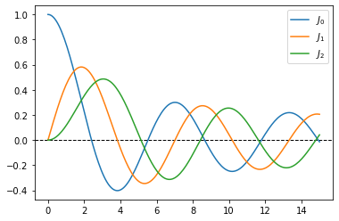

```python
import numpy as np, matplotlib.pyplot as pl
import scipy.special as spec

x = np.linspace(0,15,200)
y0 = spec.jv(0,x)
y1 = spec.jv(1,x)
y2 = spec.jv(2,x)
pl.axhline(0,color = "k", ls = "--", lw=1)

pl.plot(x, y0, label="$J_0$")
pl.plot(x, y1, label="$J_1$")
pl.plot(x, y2, label="$J_2$");
pl.legend();
```

Therefore, we get a family of solutions for the wave equation in cylindrical coordinates

$$u_{zm}(r, \theta, t) = J_m(zr) \cos(m\theta) \cos(c z t)$$

parameterized by the separation constants $m = 0,1,2,\dots$ and some number $z > 0$.

However, since the membrane is clamped along a circle of radius $a$, we need to impose the boundary condition

$$u(a, \theta, t) = 0$$

which means that we accept only solutions that have $J_m(z a) = 0$, for some values of $z = z_{mn} = x_{mn}/a$ related to the roots of Bessel functions $x_{mn}$, defined by $J_{m}(x_{mn}) = 0$.

In conclusion, the stationary wave solutions are labeled by the pair of indices $(m,n)$ and defined by

$$u_{mn}(r, \theta, t) = J_{m}\left(\frac{x_{mn}}{a} r \right) \cos(m\theta) \cos(\omega_{mn} t)$$

with characteristic frequencies $\omega_{mn} = c x_{mn}/a$.

```python
from mpl_toolkits.mplot3d import Axes3D
```

To draw the shape of standing wave we need some 3D graphics. Matplotlib has a `toolkit` that helps with that. Before using it, we set up the grids for both cartesian and cylindrical coordinate.

```python
a = 1
c = 0.75
Jm_zeros = [spec.jn_zeros(k, 10) for k in range(10)]

def circular_membrane(r, theta, m, n):
    z = Jm_zeros[m][n-1]/a
    Rg = spec.jv(m, z * r)
    Qg = np.cos(m * theta)
    return Rg*Qg

r = np.linspace(0, a, 100)
theta = np.linspace(0, 2 * np.pi, 100)

R, Theta = np.meshgrid(r, theta)
x = np.cos(Theta) * R
y = np.sin(Theta) * R
```

Let's make a table of the first modes. Pay attention to the order of frequencies. The waves have nodes in both radial and azimuthal directions. We can interpret the labeling as the corresponding number of nodes.

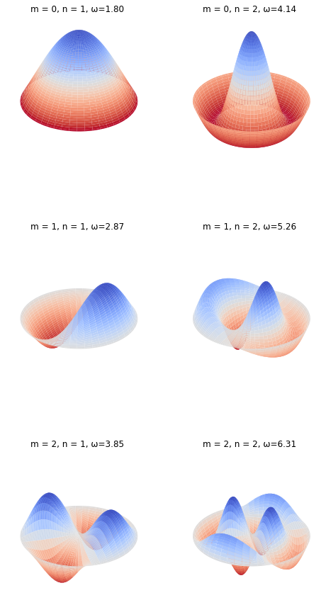

```python
fig = pl.figure(figsize=(8,16))
for m in range(3):
    for n in range(1,3):
        k = 2*m + n
        ax = fig.add_subplot(3, 2, k, projection='3d')
        z = circular_membrane(R, Theta, m, n)
        ax.plot_surface(x, y, z, cmap=pl.cm.coolwarm_r)
        ax.set_zlim(-0.24, .64)
        ax.set_xlim(-0.75, 0.75)
        ax.set_ylim(-0.75, 0.75)
        ax.axis("off")
        omega = c * Jm_zeros[m][n-1]/a
        ax.set_title(f'm = {m}, n = {n}, ω={omega:.2f}')
```

Let's try to animate the motion of the drum for a chosen standing wave. In order to do that we need to make sure that `ffmpeg` is installed. `ffmpeg` is a library that can create and manipulate video information. It knows everything about encoding, file formats, compression. Here is its website, if you are curious about it https://ffmpeg.org.

We create the video of animation in two steps. First, we use `matplotlib` do generate a figure that can hold the animation frame. Next we use the animation framework. This requires defining a function that is called every time a new frame needs to be created. Specifically, we instruct `matplotlib` to create 30 frames. This should be enough when working from the command line. A new window pops up to display the animation. Here, we want to capture the video and display in Jupyter, which is simply a browser. Inside a web page, a video is displayed with a special `<video>` element. The calculation takes a little time because because it requires 30 x 100 x 100 evaluation of bessel functions and and an equal amount of trigonometric functions. Each frame is then encoded in video.

The simplest way to check is `ffmpeg` is available is to type `conda install ffmpeg`.

[video not shown]

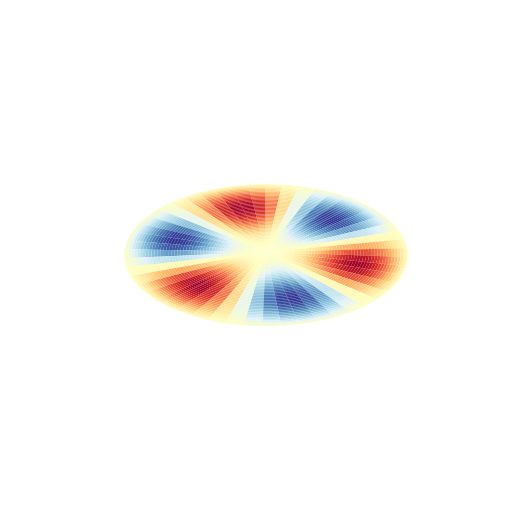

```python
import matplotlib.animation as anim
from IPython.display import HTML

def data_gen(i):
    ax.cla()
    ax.set_zlim(-0.7, 0.7)
    pl.axis("off")
    surf = ax.plot_surface(x, y, z*np.sin(2*np.pi*(i+1)/NF), cmap = 'RdYlBu', shade=True)
    return surf

m, n = 3, 1
z = circular_membrane(R, Theta, m, n)
NF = 30

fig = pl.figure(facecolor=None, figsize = (8,7))
ax = fig.add_axes(rect=(0,0,1,1), projection='3d')
ax.view_init(elev=30, azim=45)
ax.set_xlim(-0.6, 0.6)
ax.set_ylim(-0.6, 0.6)

animation = anim.FuncAnimation(fig, data_gen, range(NF), blit=False)
HTML(animation.to_html5_video())
```